# Your Digest for Sunday, Dec 17, 2023 11:59 PM

Avoid **propranolol** and **other non selective beta blocker** -> can increase uterine irritability. Atenolol has been associated with lower foetal weight. Avoid.  
Avoid **nitroprusside** -> risk of foetal cyanide poisoning.

**3-methoxy-4-hydroxy-mandelic acid** = **vanillylmandelic acid**

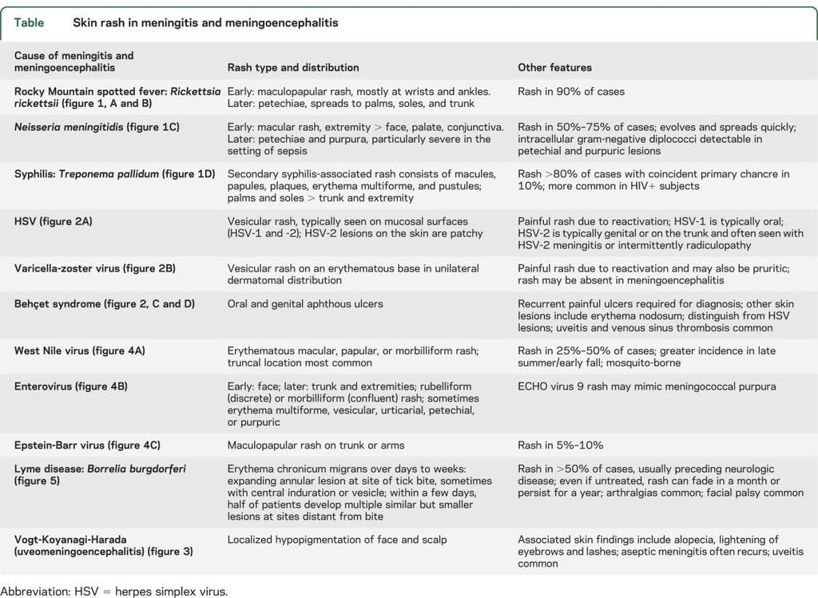

## Significance of the meningococcal rash

- **Pathogenesis**: probably because of *dermal microvessel injury* and thrombosis leading to *haemorrhagic skin necrosis* and thrombocytopenia.
- **Rash is very common**: Over 50% of patients have the rash on presentation. More on the trunk and lower body.
- Severity of rash correlates with
  - *Degree of thrombocytopenia*
  - Risk of *developing DIC*!